# Figure 3

Jaime So

2025-08-04

# Figure 3: PhIP-seq reveals common targets of anti-VSG immunity.

# A

stacked bar charts show the frequencies of enriched tile types

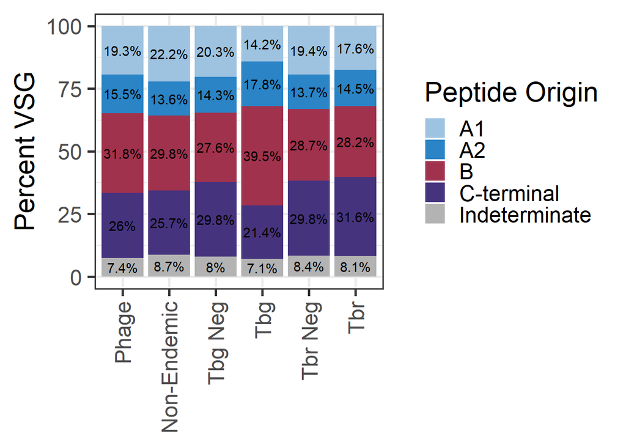

```r
# load in significantly enriched peptides
sig_peps <- read_csv("FigureData/sig_peps.csv")
plot_data <- sig_peps %>% dplyr::select(Peptide, sample) %>%
  distinct() %>% mutate(status = case_when(grepl("Pg", .$sample)~"Tbg Positive",
                                  grepl("Pr", .$sample)~"Tbr Positive",
                                  grepl("Cg", .$sample)~"Tbg Negative",
                                  grepl("Cr", .$sample)~ "Tbr Negative",
                                  grepl("NC", .$sample)~"Non-Endemic Ctl"),
                        stage = case_when(grepl("Pg1", .$sample)~"Pg1",
                                          grepl("Pg2", .$sample)~"Pg2",
                                          grepl("Pr1", .$sample)~"Pr1",
                                          grepl("Pr2", .$sample)~"Pr2",
                                          grepl("Cg", .$sample)~"Cg",
                                          grepl("Cr", .$sample)~ "Cr",
                                          grepl("NC", .$sample)~"Cn")) %>%
  group_by(status, Peptide) %>%
  mutate(n = n())

# filter for peptides that appear in more than one sample
plot_data <- merge(plot_data, plot_data %>% ungroup() %>%select(sample, status) %>% distinct() %>% group_by(status) %>% summarise(total = n())) %>% mutate(seroprevalence = (n/total)*100) %>% filter(seroprevalence >= 5)

# load in VSG tile annotations
VSG_info <- read_csv("FigureData/VSG_Tile_Classification.csv") %>%
  mutate(class = case_when(nterm_typesubtype == "1a" ~ "A1",
                           nterm_typesubtype == "1b" ~ "A1",
                           nterm_typesubtype == "1c" ~ "A1",
                           HMM_profile == "VSG-N-TypeB" | nterm_typesubtype == "B1" ~ "B",
                           TRUE ~ .$nterm_typesubtype))
# simplify by grouping all of the A1 subtypes (1a, 1b, 1c) together into just 1a. B is designated as B1 even though there are no well-established B subtypes


# if a peptide tile is N-terminal, group by NTD class

# the fold change matrix contains all detected library tiles
lib_peps <- read_csv("FigureData/fc_mat.csv") %>% .$Peptide
unenriched <- VSG_info %>% filter(pep_id %in% lib_peps) %>% mutate(stack_class = case_when(pep_region == "N-terminal" ~ class,
                                                                                                  TRUE ~ pep_region)) %>% group_by(stack_class) %>% summarise(n = n())
sig_tbg <- plot_data %>% filter(status == "Tbg Positive") %>% select(Peptide) %>% distinct()
tbg_enriched<- VSG_info %>% filter(pep_id %in% sig_tbg$Peptide) %>% mutate(stack_class = case_when(pep_region == "N-terminal" ~ class,
                                                                                                  TRUE ~ pep_region)) %>% group_by(stack_class) %>% summarise(n = n())

sig_tbr <- plot_data %>% filter(status == "Tbr Positive") %>% select(Peptide) %>% distinct()
tbr_enriched<- VSG_info %>% filter(pep_id %in% sig_tbr$Peptide) %>% mutate(stack_class = case_when(pep_region == "N-terminal" ~ class,
                                                                                                  TRUE ~ pep_region)) %>% group_by(stack_class) %>% summarise(n = n())

sig_nc <- plot_data %>% filter(status == "Non-Endemic Ctl") %>% select(Peptide) %>% distinct()
nc_enriched<- VSG_info %>% filter(pep_id %in% sig_nc$Peptide) %>% mutate(stack_class = case_when(pep_region == "N-terminal" ~ class,
                                                                                                  TRUE ~ pep_region)) %>% group_by(stack_class) %>% summarise(n = n())

sig_cg <- plot_data %>% filter(status == "Tbg Negative") %>% select(Peptide) %>% distinct()  #& seroprevalence >= 10
cg_enriched<- VSG_info %>% filter(pep_id %in% sig_cg$Peptide) %>% mutate(stack_class = case_when(pep_region == "N-terminal" ~ class,
                                                                                                  TRUE ~ pep_region)) %>% group_by(stack_class) %>% summarise(n = n())

sig_cr <- plot_data %>% filter(status == "Tbr Negative") %>% select(Peptide) %>% distinct()
cr_enriched<- VSG_info %>% filter(pep_id %in% sig_cr$Peptide) %>% mutate(stack_class = case_when(pep_region == "N-terminal" ~ class,
                                                                                                  TRUE ~ pep_region)) %>% group_by(stack_class) %>% summarise(n = n())

stacked <- rbind(unenriched %>% mutate(lib = "Phage"),
                 nc_enriched %>% mutate(lib = "Non-Endemic"),
                 cg_enriched %>% mutate(lib = "Tbg Neg"),
                 cr_enriched %>% mutate(lib = "Tbr Neg"),
                 tbg_enriched %>% mutate(lib = "Tbg"),
                 tbr_enriched %>% mutate(lib = "Tbr")) %>%
  group_by(lib) %>%
  mutate(Percent = round((n/sum(n))*100, 1))
stacked$lib <- factor(stacked$lib, levels = c("Phage", "Non-Endemic", "Tbg Neg","Tbg", "Tbr Neg", "Tbr"))

ggplot(stacked, aes(x=lib, y=Percent, fill=stack_class))+
  geom_bar(stat="identity")+
  labs(x = NULL, y = "Percent VSG", fill = "Peptide Origin")+
geom_text(aes(label = paste0(Percent, "%")), position = position_stack(vjust=0.5))+
  theme_bw(base_size = 22)+
  theme(axis.text.x = element_text(angle = 90, vjust = 0.5, hjust=1))+
  scale_fill_manual(values = c("#9EC3E0", "#2A84C6", "#A1324D", "#46337EFF", "grey70"))
```

```r
# make contingency table and perform a chi-sq test to see if frequencies differ between groups
contingency <- stacked %>% select(lib, stack_class, n) %>% .$n %>% matrix(., nrow = 5, ncol = 6, byrow = F, dimnames = list(c("A1", "A2", "B", "C-terminal", "Indeterminate"), c("Phage", "Control", "TbgNeg", "TbrNeg", "Tbg", "Tbr")))

contingency
```

```
##               Phage Control TbgNeg TbrNeg  Tbg  Tbr
## A1             9839     745   1166   1081  940 1167
## A2             7891     456    823    764 1173  957
## B             16249    1000   1590   1600 2613 1864
## C-terminal    13261     864   1716   1662 1413 2087
## Indeterminate  3797     292    460    468  468  538
```

```r
# null: frequency of enriched peptides do not differ from library
# phage represent the expected frequency of each peptide type
libexpect <- stacked %>% filter(lib == "Phage") %>% .$Percent/100
chisq_res <- chisq.test(contingency[ , 2:6], p = libexpect)
print(chisq_res)
```

```
##
##  Pearson's Chi-squared test
##
## data:  contingency[, 2:6]
## X-squared = 520.46, df = 16, p-value < 2.2e-16
```

```r
print(round(chisq_res$residuals, 2))
```

```
##               Control TbgNeg TbrNeg   Tbg   Tbr
## A1               5.31   3.53   1.95 -7.69 -1.19
## A2              -2.05  -1.28  -2.41  5.89 -1.01
## B               -1.32  -4.67  -3.16 12.39 -4.19
## C-terminal      -2.21   2.99   2.93 -9.81  5.89
## Indeterminate    1.48   0.04   1.11 -2.57  0.46
```

```r
# residuals indicate how different the observed counts are from expected, with a larger positive or negative number (further from 0) indicating larger difference

# Calculate relative contribution to chi-square statistic
contributions <- (chisq_res$observed - chisq_res$expected)^2 / chisq_res$expected
total_chi_square <- chisq_res$statistic
percentage_contributions <- 100 * contributions / total_chi_square

# percent contribution
print(round(percentage_contributions, 2))
```

```
##               Control TbgNeg TbrNeg   Tbg  Tbr
## A1               5.43   2.39   0.73 11.36 0.27
## A2               0.81   0.31   1.12  6.66 0.20
## B                0.33   4.19   1.92 29.48 3.37
## C-terminal       0.93   1.72   1.65 18.48 6.67
## Indeterminate    0.42   0.00   0.23  1.27 0.04
```

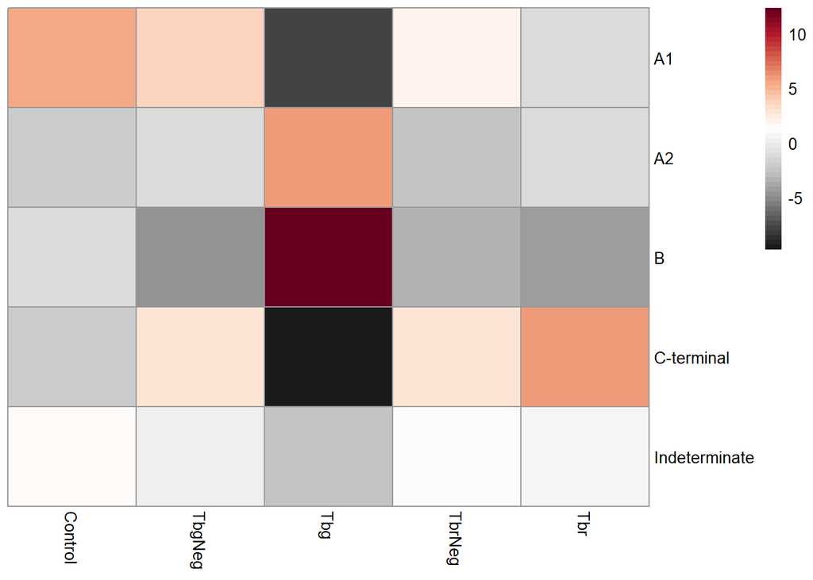

```r
pheatmap_color <- colorRampPalette(brewer.pal(n=11, name = "RdGy"))(50)
pheatmap(round(chisq_res$residuals, 2)[, c(1, 2, 4, 3, 5)],
         cluster_rows = F,
         cluster_cols = F,
         col = rev(pheatmap_color)
         )
```

The peptides enriched in Tbg infected cohort contribute the most to the chi-sq statistic. Non endemic controls, endemic controls for both tbg and tbr cohorts, and the Tbr positive cohort are all not very meaningfully different from phages. Significantly more type B NTD peptides enrich in Tbg positive samples while there are lower than expected counts of type A1 NTD and CTD peptides.

# Mapping and Plotting Putative Epitopes

Epitopes were determined using an igraph network building approach which clustered peptides based on presence of shared homologous sequence. We pulled the shared sequences from these peptide clusters and defined them as putative epitopes. Sets of enriched epitopes were defined for each individual patient. Since the library contains many sequences from incomplete VSG (protein fragments/pseudogenes) the tile coordinates do not always directly correspond to VSG structural features. This is why we decided to map epitopes back to full length VSG to identify regions of highest immunogenicity.

## ProteoMapper

terminal commands for running proteoMapper

```r
# txt files generated containing the motifs identified for each sample
# filenames: sampleID_motif_sequences.txt
# each line of the motif txt file contains a  motif sequence

# index VSG fasta file as mapping reference
# Use the fasta of all VSG sequences used to produce library tiles
~/clips.pl -V ../All_tiled_VSG.fasta

# map each motif fasta to the indexed VSG reference
for FILE in *_motif_sequences.txt
do
        perl ~/promast.pl -f 1 All_tiled_VSG.fasta $FILE > $FILE.tsv
done

# concatenate all proteomapper outputs into a single table containing peptide sequence, ref protein hit, and location which is the mapping start coordinate
# be sure to also record sample IDs in the combined table
```

proteomapper output includes all input sequences in the output report, if they failed to map to reference they will be designated “UNMAPPED” instead of indicating protein

## Recover unmapped with BLASTp

terminal blast command

```r
$ blastp -subject All_tiled_VSG.fasta -query unmapped_motif_sequences.fasta -out unmapped_motifs_Blastp.csv -outfmt "10 qseqid sseqid sstart send evalue"
```

parse outputs in R

```r
unmapped <- proteomapper %>% filter(protein == "UNMAPPED")
# write unmapped sequences to a fasta file
test <- data.frame(fasta_id = as.character(),
                   sequence = as.character())
for (i in 1:length(unique(unmapped$sample))){
  x <- unmapped %>% filter(sample == unique(unmapped$sample)[i])
  x$id <- paste(rep("motif", nrow(x)), c(1:nrow(x)), sep = "_")
  x$fasta_id <- paste(x$clustername, x$id, sep = "_")
  test <- rbind(test, x %>% select(fasta_id, sequence))
}

y <- AAStringSet(test$sequence)
names(y) <- test$fasta_id
writeXStringSet(y, filepath = "unmapped_motif_sequences.fasta", append=FALSE, compress=FALSE, compression_level=NA, format="fasta")

unmapped_res <- read_csv("unmapped_motifs_Blastp.csv", col_names = F)
colnames(unmapped_res) <- c("motif_id", "protein", "start", "end", "evalue")

unmapped_res <- unmapped_res %>% filter(evalue < 0.001)
unmapped_res$clustername <- str_split_fixed(unmapped_res$motif_id, "_motif", 2)[, 1]
unmapped_res$sample <- str_split_fixed(unmapped_res$clustername, "_(?=[^_]+$)", 2)[, 1]

# there are 16835 sequences in the file "unmapped_motif_sequences.fasta"
# how many peptides now remain unmapped?
unique(unmapped_res$motif_id) %>% length()
# 1309 motifs still fail to map with evalue cutoff of 0.001
# a very small proportion of the total motifs identified
```

## Cd-hit Clustering

Repetitive, highly similar VSG may skew the mapping results. Collapse highly similar VSGs into a single representative with cd-hit so those are only counted one time. We are most bothered with VSGs that are essentially exactly the same, so cluster by a high identity threshold.

```r
# example console command for 90% peptide identity clustering from cd-hit wiki
% cd-hit -i db    -o db_90 -c 0.9 -n 5 -g 1 -G 0 -aS 0.8  -d 0 -p 1 -T 16 -M 0 > db_90.log

# the command I used to cluster highly similar full VSG sequences from the motif map reference fasta used to generate tiles
% cd-hit -i All_tiled_VSG.fasta -o clustered_VSG.fasta -c 0.95 -G 0 -g 1 -aS 0.8 -n 5 -d 0 -M 0 -p 1

# note that the representative sequence reported by cd-hit will always be the longest one
# cluster members must cover at least 80% of the representative sequence (-aS 0.8) at 95% identity (-c 0.95)

# the fasta file cdhit output contains only representative sequences
# print these ids and filter dataframes of mapped motifs to exclude all the clustered VSGS that are essentially exactly the same
filter_VSG <- read_table("FigureData/clustered_VSG_representativeID.txt", col_names = F) %>% select(X1)
colnames(filter_VSG) <- "VSGid"

filter_VSG$VSGid <- sub(">", "", filter_VSG$VSGid)
```

## Combine and Summarize

```r
# combine the dataframes for all motif alignments: proteomapper output, blastp output, and singleton tile info
VSG_cov <- rbind(unmapped_res %>% select(sample, protein, start, end),
proteomapper %>% filter(!protein == "UNMAPPED") %>% select(sample, protein, start, end)) %>%
  rbind(singletons %>% select(sample, protein, start, end))

# find the length of each VSG
VSG_len <- read_csv("FigureData/VSG_Tile_Classification.csv") %>% filter(pro_id %in% unique(VSG_cov$protein)) %>% dplyr::rename("protein"="pro_id")

# function for reading and summarizing coverage output - produces ranges for each patient which can be plotted
MotifMap <- function(inputname){
  x <- VSG_cov %>% filter(sample == inputname)
  y <- VSG_len %>% filter(protein %in% unique(x$protein))
  # use iranges package for visualization
  plotR <- data.frame(start = double(),
                      end = double(),
                      width = double(),
                      seq_ID = character())
  for (i in 1:length(y$protein)) {
    irR <- IRanges(x[x$protein == y$protein[i], ] %>%
                   select(protein, start, end) %>%
                   distinct() %>%
                   .$start,
                 end = x[x$protein == y$protein[i], ] %>%
                   select(protein, start, end) %>%
                   distinct() %>%
                   .$end)
    # collapse overlapping regions to calculate seq_ID coverage
    cov <- IRanges::reduce(irR) %>% as.data.frame()
    cov <- cov %>% mutate(protein = y$protein[i])
    plotR <- rbind(plotR, cov)
    }
  plotR$sample <- inputname
  plotR <- merge(plotR, y)
  return(plotR)
}

# summarise ranges for all samples
# write results to a file instead of using memory
for (i in 1:length(unique(VSG_cov$sample))){
  test <- MotifMap(unique(VSG_cov$sample)[i]) %>% filter(protein %in% filter_VSG$VSGid) # filter to exclude redundant VSG
  write_csv(test, file = "all_samples_mapped_ranges.csv", append = T)
}
```

## Mapping Results

```r
VSGs_mapped <- read_csv("FigureData/all_samples_mapped_ranges.csv", col_names = T)
# add disease stage column
VSGs_mapped <- VSGs_mapped %>% mutate(stage = case_when(grepl("Pg1", .$sample)~"Pg1",
                                                        grepl("Pg2", .$sample)~"Pg2",
                                                        grepl("Pr1", .$sample)~"Pr1",
                                                        grepl("Pr2", .$sample)~"Pr2",
                                                        grepl("Cg", .$sample)~"Cg",
                                                        grepl("Cr", .$sample)~ "Cr",
                                                        grepl("NC", .$sample)~"Cn"))
```

## Calculate VSG coverage

Made a function that counts overlapping ranges along the full VSG protein sequence by group for a specified VSG. Right now it groups by disease stage/cohort. Function summarizes one VSG at a time, but works quickly and can easily iterate through larger lists of VSGs.

Goal: Map positions and color by group. Start off grouping by disease stage. Make coverage histograms for all VSGs, then normalize.

```r
cov_histogram <- function(mapdf, meta, VSGname){
  x <- mapdf %>% filter(protein == VSGname)
  x <- merge(x, meta)
  y <- mapdf %>% filter(protein == VSGname) %>% select(protein, seq_length, nterm_seq_length) %>% distinct()
  # use iranges package for visualization
  plotR <- data.frame(value = double(),
                      position = double(),
                      stage = character())
  for (i in 1:length(unique(x$stage))) {
    irR <- IRanges(x[x$stage == unique(x$stage)[i], ] %>%
                   .$start,
                 end = x[x$stage == unique(x$stage)[i], ] %>%
                   .$end)
    # count overlaps
    cov <- IRanges::coverage(irR) %>% as.data.frame()
    cov <- cov %>% mutate(position = rownames(cov), stage = unique(x$stage)[i])
    plotR <- rbind(plotR, cov)
    }
  plotR <- plotR %>% mutate(protein = VSGname)
  plotR <- merge(plotR, y)
  return(plotR)
}

# example

## subtype A1a
A1a <- VSGs_mapped %>% select(protein, subtype) %>% distinct() %>% filter(subtype == "1a") %>% .$protein
## look at coverage for all type A1a VSG by disease status
A1a_histograms <- data.frame(protein = as.character(),
                             value = as.double(),
                             position = as.double(),
                             stage = as.character(),
                             seq_length = as.double(),
                             nterm_seq_length = as.double())
## iterate through the list of type A1a VSGs
for (i in 1:length(A1a)){
  test <- cov_histogram(VSGs_mapped, map_meta, A1a[i])
  A1a_histograms <- rbind(A1a_histograms, test)
}

#dataframe A1a_histograms is the raw coverage output for all Type A1a VSG
# it counts ("value" column) the number of samples per disease stage with hits at each position along the VSG
# normalize position by subtracting the NTD coordinate
A1a_histograms$position <- as.double(A1a_histograms$position)
A1a_histograms$position_norm <- A1a_histograms$position - A1a_histograms$nterm_seq_length
# since calculating this took an eternity, write result to a csv

# make data frames for all VSG NTD subtypes and concatenate them to produce final coverage dataframe
# normalize counts by patient cohort size and the total number of enriched VSGs per NTD type
```

# B

Tbr is something of a negative result since we cannot model the CTD, where mapped Tbr epitopes are the most seroprevalent, with high confidence using colabfold. Show the full dataset with all cohorts in the supplement and highlight the NTD epitope enrichment demonstrated by Tbg as a main figure. Simplify by plotting only the delta between gHAT and non-endemic control signal. We will only be modeling NTD monomers, so exclude showing mapping to the CTD to avoid confusion.

```r
mapped_epitopes <- read_csv("FigureData/all_mapped_epitopes_normalized.csv")
# Identify the most seroprevalent full-length VSGs per type and cohort to use for alphafold modeling purposes

cohorts <- VSGs_mapped %>% select(sample, stage) %>% distinct() %>% group_by(stage) %>% summarise(stage_total = n())
mapped_sero <- VSGs_mapped %>% select(protein, sample, stage) %>% distinct()
stage_mapped_sero <- merge(mapped_sero %>% group_by(stage, protein) %>% summarise(n_stage = n()), cohorts) %>% mutate(seroprevalence = (n_stage/stage_total)*100)
stage_mapped_sero <- inner_join(stage_mapped_sero, VSGs_mapped %>% select(protein, seq_length, nterm_seq_length, subtype) %>% distinct(), by = "protein")

# find the seroprevalent full-length A1a VSGs to model
rbind(stage_mapped_sero %>% filter(subtype == "1a" & stage == "Pg1" & nterm_seq_length > 200) %>% arrange(desc(seroprevalence)) %>% head(n=10),
      stage_mapped_sero %>% filter(subtype == "1a" & stage == "Pg2" & nterm_seq_length > 200) %>% arrange(desc(seroprevalence)) %>% head(n=10)) %>%
  .$protein %>% unique()
```

```
##  [1] "KC434779.1"      "KC434555.1"      "Tbb927VSG-161"   "KC434860.1"
##  [5] "Tb427VSG-541"    "Tb427VSG-616"    "Tbb1125VSG-4259" "Tbb927VSG-260"
##  [9] "KC434552.1"      "Tb427VSG-3296"   "KC434824.1"      "Tbb1125VSG-4727"
## [13] "Tb427VSG-530"
```

```r
# A1b
rbind(stage_mapped_sero %>% filter(subtype == "1b" & stage == "Pg1" & nterm_seq_length > 200) %>% arrange(desc(seroprevalence)) %>% head(n=10),
      stage_mapped_sero %>% filter(subtype == "1b" & stage == "Pg2" & nterm_seq_length > 200) %>% arrange(desc(seroprevalence)) %>% head(n=10)) %>%
  .$protein %>% unique()
```

```
##  [1] "Tb427VSG-1753"    "Tbb1125VSG-389"   "Tb427VSG-3078"    "Tbb1125VSG-1331"
##  [5] "Tb427VSG-3168"    "TevSTIB805.9.430" "Tb427VSG-1228"    "Tb427VSG-1255"
##  [9] "Tbb1125VSG-4312"  "Tbb1125VSG-348"   "Tbb1125VSG-1345"  "Tbb1125VSG-6309"
```

```r
# A1c
rbind(stage_mapped_sero %>% filter(subtype == "1c" & stage == "Pg1" & nterm_seq_length > 200) %>% arrange(desc(seroprevalence)) %>% head(n=10),
      stage_mapped_sero %>% filter(subtype == "1c" & stage == "Pg2" & nterm_seq_length > 200) %>% arrange(desc(seroprevalence)) %>% head(n=10)) %>%
  .$protein %>% unique()
```

```
##  [1] "Tbb1125VSG-2612"        "TevSTIB805.6.5720"      "KC434764.1"
##  [4] "Tbb1125VSG-4911"        "TevSTIB805.11_01.18050" "XM_840544.1"
##  [7] "Tbb1125VSG-4203"        "Tb10.v4.0117"           "Tb427VSG-391"
## [10] "Tbb1125VSG-6218"        "Tb11.v5.0143.1"         "Tb427VSG-1189"
## [13] "Tb427VSG-590"
```

```r
# A2
rbind(stage_mapped_sero %>% filter(subtype == "A2" & stage == "Pg1" & nterm_seq_length > 200) %>% arrange(desc(seroprevalence)) %>% head(n=10),
      stage_mapped_sero %>% filter(subtype == "A2" & stage == "Pg2" & nterm_seq_length > 200) %>% arrange(desc(seroprevalence)) %>% head(n=10)) %>%
  .$protein %>% unique()
```

```
##  [1] "KC434631.1"       "KC434732.1"       "Tbb927VSG-2130"   "M83696.1"
##  [5] "M83697.1"         "Tb427VSG-1566"    "M83694.1"         "Tb427VSG-738"
##  [9] "Tbb1125VSG-1683"  "TevSTIB805.3.210" "Tbb1125VSG-233"   "Tbb1125VSG-63"
```

```r
# B
rbind(stage_mapped_sero %>% filter(subtype == "B1" & stage == "Pg1" & nterm_seq_length > 200) %>% arrange(desc(seroprevalence)) %>% head(n=10),
      stage_mapped_sero %>% filter(subtype == "B1" & stage == "Pg2" & nterm_seq_length > 200) %>% arrange(desc(seroprevalence)) %>% head(n=10)) %>%
  .$protein %>% unique()
```

```
##  [1] "Tbb1125VSG-4808"        "Tb427VSG-1426"          "Tbb1125VSG-4709"
##  [4] "Tb927.11.19480"         "Tbb1125VSG-219"         "Tbb1125VSG-4151"
##  [7] "Tbb1125VSG-4166"        "Tbb1125VSG-4202"        "Tb427VSG-1011"
## [10] "Tb427VSG-1122"          "Tbb1125VSG-252"         "Tbb1125VSG-503"
## [13] "Tbb1125VSG-6"           "TevSTIB805.11_01.18380" "Tb427VSG-3209"
## [16] "Tb427VSG-487"           "Tbb1125VSG-1511"        "Tb427VSG-1090"
## [19] "Tb427VSG-1136"          "Tb427VSG-2106"
```

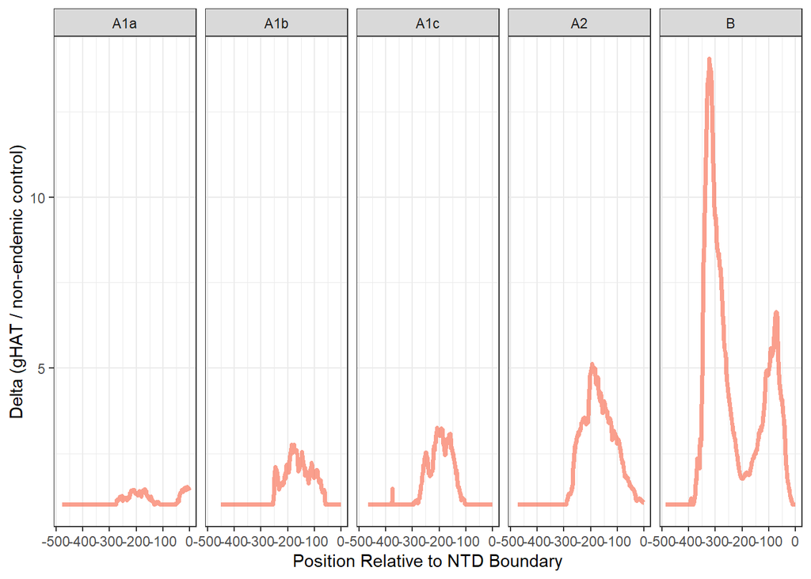

```r
# color models using a gradient that represents the difference (fold change) in normalized amplitude between infected cohorts and non-endemic controls

make_gradients <- function(NTDtype, cohort){
  x <- data.frame(coord = mapped_epitopes %>% filter(subtype == NTDtype, stage == paste0(cohort,"1")) %>% .$position_norm,
                     stage1 = mapped_epitopes %>% filter(subtype == NTDtype, stage == paste0(cohort,"1")) %>% .$norm_count) %>%
  full_join(data.frame(coord = mapped_epitopes %>% filter(subtype == NTDtype, stage == paste0(cohort,"2")) %>% .$position_norm,
                       stage2 = mapped_epitopes %>% filter(subtype == NTDtype, stage == paste0(cohort,"2")) %>% .$norm_count)) %>%
  full_join(data.frame(coord = mapped_epitopes %>% filter(subtype == NTDtype, stage == "Cn") %>% .$position_norm,
                       Cn = mapped_epitopes %>% filter(subtype == NTDtype, stage == "Cn") %>% .$norm_count))
  x <- x %>% replace(is.na(.), 0)
  x$avg <- rowMeans(x[ , c(2, 3)])
  x <- x %>% mutate(color = avg/Cn) %>% select(coord, color)
  return(x)
}

TbgA1a <- make_gradients("1a", "Pg")
TbgA1b <- make_gradients("1b", "Pg")
TbgA1c <- make_gradients("1c", "Pg")
TbgA2 <- make_gradients("A2", "Pg")
TbgB <- make_gradients("B1", "Pg")
# we will need to format this delta value so it can be imported into chimeraX as a mapping attribute for making residue coloring gradients

#write_csv(TbgA1a, file = "TbgA1a_gradient.csv")
#write_csv(TbgA1b, file = "TbgA1b_gradient.csv")
#write_csv(TbgA1c, file = "TbgA1c_gradient.csv")
#write_csv(TbgA2, file = "TbgA2_gradient.csv")
#write_csv(TbgB, file = "TbgB_gradient.csv")

plot_delta <- rbind(TbgA1a %>% mutate(subtype = "A1a"),
                    TbgA1b %>% mutate(subtype = "A1b"),
                    TbgA1c %>% mutate(subtype = "A1c"),
                    TbgA2 %>% mutate(subtype = "A2"),
                    TbgB %>% mutate(subtype = "B"))
# fix the values which are NA or inf(from dividing by 0)
plot_delta$color <- replace_na(plot_delta$color, 1)
plot_delta$color <- replace(plot_delta$color, (plot_delta$color < 1 | plot_delta$color == "Inf") ,1)

plot_delta %>% filter(coord <= 0 & color >= 1) %>%
  ggplot(aes(x = coord, y = color)) +
  geom_line(linewidth = 1.4, alpha = 0.7, color = "#F8765CFF") +
  facet_wrap(~subtype, nrow = 1) +
  xlab("Position Relative to NTD Boundary") +
  ylab("Delta (gHAT / non-endemic control)") +
  theme_bw()
```

# Figure S5

To make the plots more generalized and easier to read, plot the NTD boundary as position 0 then calculating positions relative to it so N-terminal spans will be (-) and C-terminal (+). Plot along the full length of the VSG, not just the NTD. Notice how the regions of greatest amplitude of mapped epitopes for rHAT patients tend to be within the CTD.

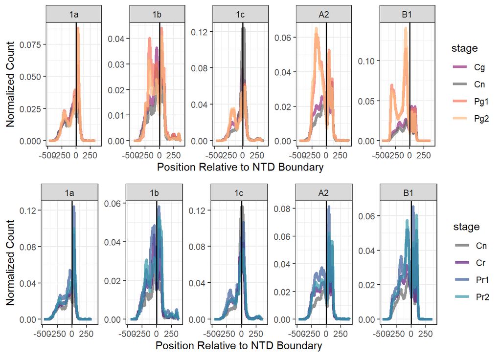

```r
pTbr <- mapped_epitopes %>% filter(stage == "Pr1" | stage == "Pr2" | stage == "Cr" | stage == "Cn") %>%
  ggplot(aes(x = position_norm, y = norm_count, color = stage)) +
  geom_line(linewidth = 1.4, alpha = 0.7) +
  geom_vline(aes(xintercept = 0), linetype = "solid", color = "black", linewidth = 0.6) +
  scale_color_manual(values = c("grey40", "#5F187FFF", "#395D9CFF", "#3497A9FF")) +
  #scale_x_continuous() +
  facet_wrap(~subtype, nrow = 1, scales = "free_y") +
  #ggtitle("VSG NTD Type") +
  xlab("Position Relative to NTD Boundary") +
  ylab("Normalized Count") +
  theme_bw()

pTbg <- mapped_epitopes %>% filter(stage == "Pg1" | stage == "Pg2" | stage == "Cg" | stage == "Cn") %>%
  ggplot(aes(x = position_norm, y = norm_count, color = stage)) +
  geom_line(linewidth = 1.4, alpha = 0.7) +
  geom_vline(aes(xintercept = 0), linetype = "solid", color = "black", linewidth = 0.6) +
  scale_color_manual(values = c("#982D80FF", "grey40", "#F8765CFF", "#FEBA80FF")) +
  #scale_x_continuous() +
  facet_wrap(~subtype, nrow = 1, scales = "free_y") +
  #ggtitle("VSG NTD Type") +
  xlab("Position Relative to NTD Boundary") +
  ylab("Normalized Count") +
  theme_bw()

plot_grid(pTbg, pTbr, nrow = 2)
```

By [Jaime So](https://github.com/JSoSci/) for the [Mugnier Lab](https://www.mugnierlab.org/)

*jso4@jhmi.edu*